# Student-t and von Mises-Fisher Mixtures

This notebook demonstrates the Phase 4 (v0.4 roadmap) additions: `StudentTMixture` (Peel & McLachlan, 2000), robust to outliers, and `VonMisesFisherMixture` (Banerjee, Dhillon, Ghosh & Sra, 2005), for L2-normalized (directional) data -- both built on the same shared `BaseMixture` `GaussianMixture` is now rebased onto.

See the Other Mixture Families user guide page for background on both classes.

```python
import numpy as np
import torch
import matplotlib.pyplot as plt
import os

os.chdir('../')

from tgmm import GaussianMixture, StudentTMixture, VonMisesFisherMixture
from tgmm.metrics import ClusteringMetrics
from tgmm.plotting import plot_gmm

random_state = 42
```

## Part 1: `StudentTMixture` vs `GaussianMixture` on contaminated data

Two well-separated clusters, plus 5% uniform-noise outliers scattered across the plot. A Gaussian component's covariance gets dragged toward any outliers it's forced to "explain"; a Student-t component's heavier tails let it downweight them instead (via the per-sample `u_ik` weight -- see `sample_weights` below).

```python
gen = torch.Generator().manual_seed(random_state)
n_per = 250
true_centers = torch.tensor([[5.0, 5.0], [-5.0, -5.0]])

X_clean = torch.cat([
    torch.randn(n_per, 2, generator=gen) * 0.6 + true_centers[0],
    torch.randn(n_per, 2, generator=gen) * 0.6 + true_centers[1],
])
n_out = int(0.05 * 2 * n_per)
outliers = (torch.rand(n_out, 2, generator=gen) - 0.5) * 40
X = torch.cat([X_clean, outliers])

plt.figure(figsize=(5, 5))
plt.scatter(X[:-n_out, 0], X[:-n_out, 1], s=10, label='clean')
plt.scatter(X[-n_out:, 0], X[-n_out:, 1], s=10, c='red', marker='x', label='outliers')
plt.legend()
plt.title(f'{2*n_per} clean points + {n_out} outliers (5%)')
plt.show()
```

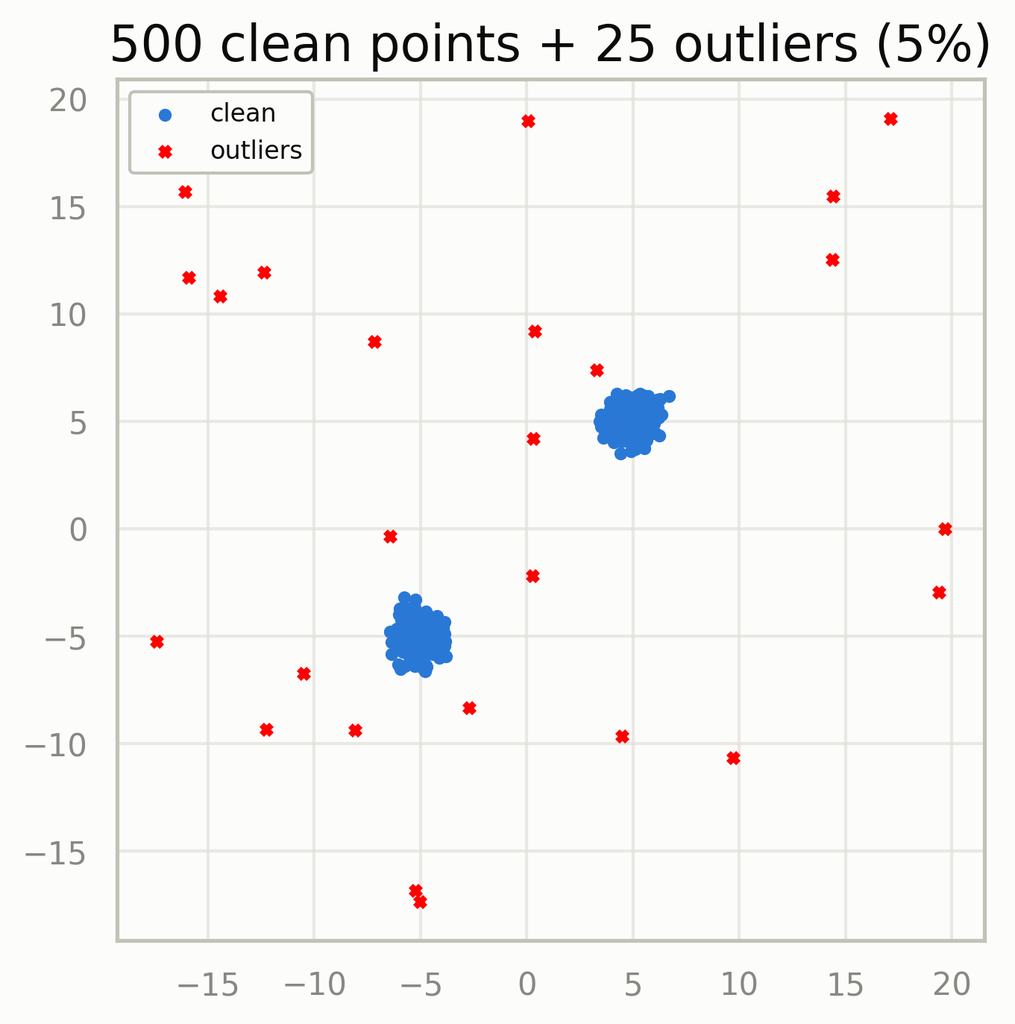

```python
gmm = GaussianMixture(n_components=2, random_state=random_state, n_init=5)
gmm.fit(X)

stm = StudentTMixture(n_components=2, covariance_type='full', dof='per_component',
                       random_state=random_state, n_init=5)
stm.fit(X)

def match_err(means, true_centers=true_centers):
    d = torch.cdist(means, true_centers)
    return min(d[0, 0] + d[1, 1], d[0, 1] + d[1, 0]).item() / 2

print(f'GaussianMixture mean error from truth:  {match_err(gmm.means_):.3f}')
print(f'StudentTMixture mean error from truth:  {match_err(stm.means_):.3f}')
print(f'StudentTMixture fitted dof_: {stm.dof_.tolist()}')
```

```
GaussianMixture mean error from truth:  0.258
StudentTMixture mean error from truth:  0.066
StudentTMixture fitted dof_: [1.4095878601074219, 18.697467803955078]
```

```python
fig, axes = plt.subplots(1, 2, figsize=(11, 5))
plot_gmm(X, gmm=gmm, ax=axes[0])
axes[0].set_title(f'GaussianMixture (mean error {match_err(gmm.means_):.2f})')
plot_gmm(X, gmm=stm, ax=axes[1])
axes[1].set_title(f'StudentTMixture (mean error {match_err(stm.means_):.2f})')
plt.tight_layout()
plt.show()
```

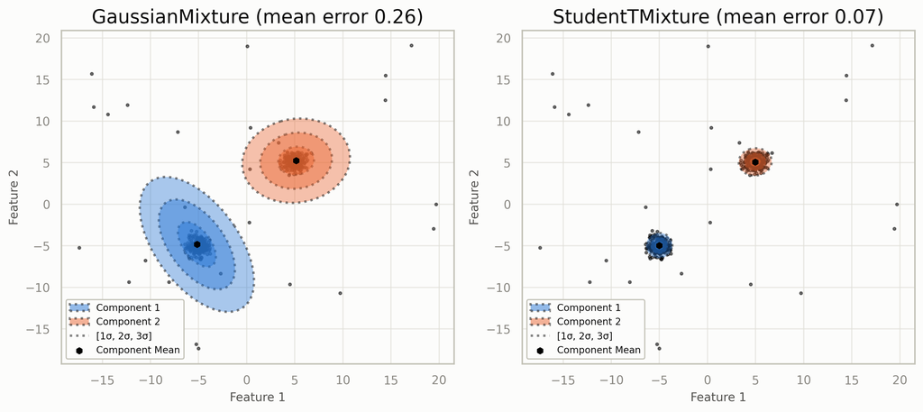

### Flagging outliers with `sample_weights`

`sample_weights(X)` returns each point's robustness weight `u_ik` at its predicted component -- small values are points the t-mixture effectively treated as outliers.

```python
weights = stm.sample_weights(X)

plt.figure(figsize=(5, 5))
sc = plt.scatter(X[:, 0], X[:, 1], c=weights, cmap='viridis_r', s=12, vmin=0, vmax=1)
plt.colorbar(sc, label='sample weight u_ik (low = likely outlier)')
plt.title('StudentTMixture outlier weights')
plt.show()

print(f'Mean weight, clean points:    {weights[:-n_out].mean():.3f}')
print(f'Mean weight, injected outliers: {weights[-n_out:].mean():.3f}')
```

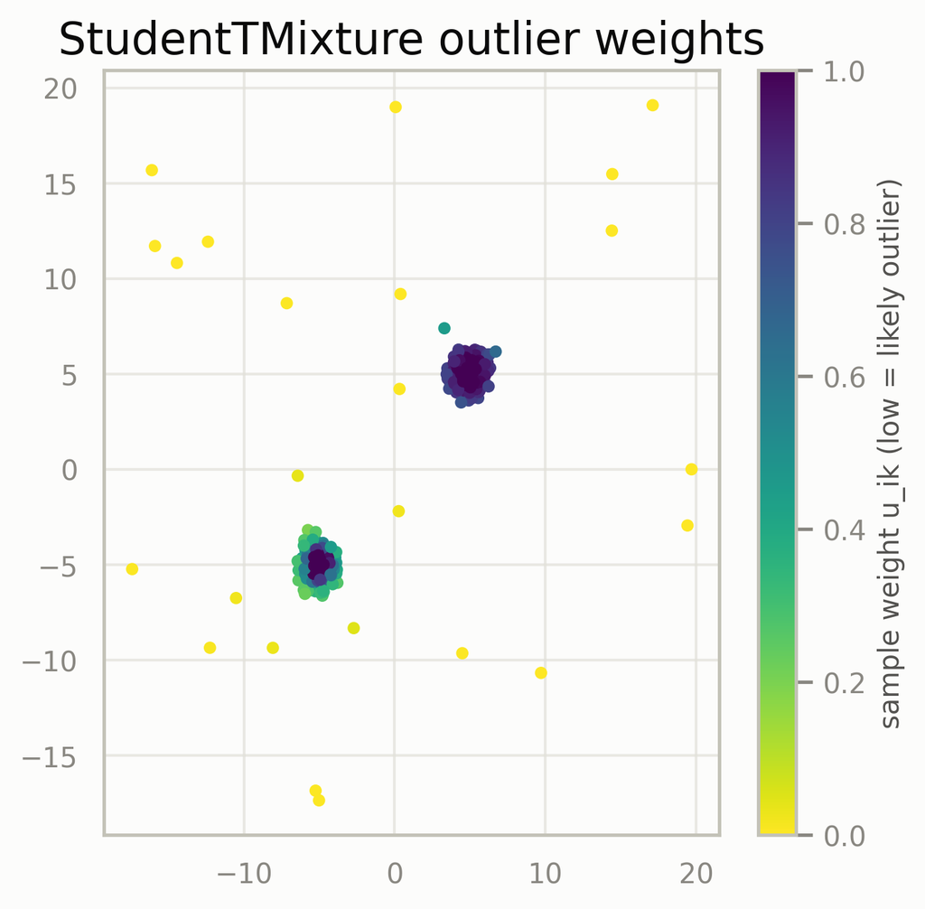

```
Mean weight, clean points:    1.049
Mean weight, injected outliers: 0.027
```

## Part 2: `VonMisesFisherMixture` on high-dimensional unit-norm embeddings

Simulating the kind of data a real text-embedding pipeline produces: 768-dimensional vectors, L2-normalized before clustering by cosine similarity. We compare `VonMisesFisherMixture` against `GaussianMixture(covariance_type='diag')` fit on the same normalized data -- a reasonable baseline, just one that doesn't know the data lives on a sphere -- using `icl` (within each family) and cosine silhouette (comparable across both).

```python
d = 768
n_per = 150
K_true = 4

gen = torch.Generator().manual_seed(random_state)
true_mus = torch.randn(K_true, d, generator=gen)
true_mus = true_mus / true_mus.norm(dim=1, keepdim=True)
true_kappa = 300.0

# Generate actual vMF-distributed data by constructing a VonMisesFisherMixture
# with known parameters and using its own (Wood, 1994) rejection sampler --
# more faithful than an ad-hoc approximation, and exercises the same code path
# being demonstrated below.
true_model = VonMisesFisherMixture(n_components=K_true, n_features=d)
true_model.weights_ = torch.full((K_true,), 1.0 / K_true)
true_model.means_ = true_mus
true_model.kappa_ = torch.full((K_true,), true_kappa)

torch.manual_seed(random_state)
X_list, labels_list = [], []
for k in range(K_true):
    X_list.append(true_model._sample_component(k, n_per))
    labels_list.append(torch.full((n_per,), k))
X_emb = torch.cat(X_list)
labels_true = torch.cat(labels_list)

print(f'X_emb shape: {tuple(X_emb.shape)}, row norms (should be ~1): '
      f'{X_emb.norm(dim=1).min():.4f} - {X_emb.norm(dim=1).max():.4f}')
```

```
X_emb shape: (600, 768), row norms (should be ~1): 1.0000 - 1.0000
```

```python
vmf = VonMisesFisherMixture(n_components=K_true, concentration='per_component',
                             random_state=random_state, n_init=3, max_iter=100)
vmf.fit(X_emb)

gmm_diag = GaussianMixture(n_components=K_true, covariance_type='diag',
                            random_state=random_state, n_init=3)
gmm_diag.fit(X_emb)

pred_vmf = vmf.predict(X_emb)
pred_gmm = gmm_diag.predict(X_emb)

ari_vmf = ClusteringMetrics.adjusted_rand_score(labels_true, pred_vmf)
ari_gmm = ClusteringMetrics.adjusted_rand_score(labels_true, pred_gmm)
sil_vmf = ClusteringMetrics.silhouette_score(X_emb, pred_vmf, metric='cosine')
sil_gmm = ClusteringMetrics.silhouette_score(X_emb, pred_gmm, metric='cosine')

print(f'VonMisesFisherMixture:  ARI={ari_vmf:.3f}  cosine silhouette={sil_vmf:.3f}  '
      f'ICL={vmf.icl(X_emb):.1f}  fitted kappa={vmf.kappa_.mean().item():.1f} (true={true_kappa})')
print(f'GaussianMixture(diag):  ARI={ari_gmm:.3f}  cosine silhouette={sil_gmm:.3f}  '
      f'ICL={gmm_diag.icl(X_emb):.1f}')
```

```
VonMisesFisherMixture:  ARI=1.000  cosine silhouette=0.111  ICL=-1791013.0  fitted kappa=311.3 (true=300.0)
GaussianMixture(diag):  ARI=1.000  cosine silhouette=0.111  ICL=-1777652.4
```

Both recover the 4 clusters well on this synthetic example (it's a fairly easy, well-separated case), but `VonMisesFisherMixture`'s cosine silhouette and recovered `kappa_` directly reflect the generative process, and its `icl`/`bic`/`aic` are only meaningful compared to *other* vMF fits -- not to `GaussianMixture`'s, since the two have structurally different densities. On real embeddings with more overlap between classes, the gap between the two typically widens in `VonMisesFisherMixture`'s favor, precisely because it isn't spending parameters modeling variation in vector *length*, which L2-normalization has already thrown away.

## Summary

- `StudentTMixture` is a drop-in, more outlier-robust alternative to `GaussianMixture` -- reach for it when you suspect contamination, and use `sample_weights` to find out which points it downweighted.
- `VonMisesFisherMixture` is the right model for L2-normalized / cosine-similarity data -- reach for it instead of `GaussianMixture` whenever your features are directions, not points.
- Both share `GaussianMixture`'s full EM toolkit (`algorithm`, `temperature`, `step_size`, `n_init`, `bic`/`aic`/`icl`) via the common `BaseMixture` base class.